# Demonstration of Issues in Robust Statistics and Hypothesis Testing

Matt Multach

2021-11-19

## Preamble and Setup

#### A note on formatting

This document makes use of **bolding**, *italics*, and “quotations” to help distinguish different types of items being referenced.

- **bolding** will be used when referencing a new term or concept for the first time. Subsequent references to each term/concept will *not* be bolded.
- *italics* will be used primarily for emphasis.
- ‘single quotations’ will be used to clarify specific arguments for a function, or specific parameters of a mathemtical/statistical formulation
- Inline references to code (functions, objects, specific commands, etc.) will use **`code_chunk_formatting`** in **`bolded blue font`**
- Inline references to packages will similarly use *`code_chunk_formatting`*, except in *`italicized red font`*
- References to other documents in this repository will use `code_chunk_formatting` in `un-italicized, un-bolded, green font`

Re: spacing and line breaks - I’m pretty heterogeneous in my application of line breaks and spacing, in a way that is idiosyncratic to my own code practice. The most important aspects of my spacing and line breaks are detailed below.

I generally put spaces between code inputs I consider “sufficiently distinct”. This improves readability generally, but I find it particularly helpful for debugging. Note, however, that spaces are generally trivial in between distinct code inputs in R, although this is not universally the case. Multi-character code inputs, such as the pointer **`<-`** and most logical operators, *cannot* include spaces in between components of the code input. Note also that whitespace *is* meaningful in other programming languages, and so this convention should be considered with caution in your own practice.

Generally, I use line breaks to:

- Break up separate arguments for a single command/function or chain of operations
- To clearly distinguish between different closing parentheses, brackets, squigglies, etc., since RStudio will automatically tab each closing piece to match its opener.

#### Packages

First, let’s load the necessary packages. Links to more information about each packages and helpful guides (where applicable) can be found in `00B_Package_Descr_Refs`. Appropriate references for each package can be found in the “References” section at the end of this document.

```r
# This chunk loads the packages used in this workbook
library(xaringan)   # Allows active preview of report in RStudio
#library(psych)      # A package with some practical stats function
library(stats)      # Another library of practical stats functions, particularly power.t.test
library(magrittr)   # Used for piping
library(purrr)      # Used for mapping functions efficiently
library(data.table) # For more streamlined data structures
library(rlang)      # For parse_expr() to parse data name in k-fold subsetting functions
library(gridExtra)    # For displaying grids of objects
library(grid)         # For creating a title for multiplot grid
library(ggplot2)      # For generating and manipulation graphical objects
```

Note that if you do not have any of the listed packages, you should install them using **`install.packages("pkg-name-in-quotes-here")`**.

## Introduction

This file demonstrates a simplified example of concerns studied in robust hypothesis testing and statistical methods.

Below is an introduction to variable selection and robust statistical methods for contextualizing effective selection tools. This serves as a broader introduction to the issues motivating my doctoral research and, consequently, this respository. Note that a lot of the introduction and review below is lifted essentially whole-cloth from my dissertation, Multach (2021), aside form some formatting changes necessitated by the transition from LaTeX to Markdown.

The importance of proper variable selection, and thereby effective model selection, is two-fold for the understanding of a data-generating process. Qualitatively, selecting the correct predictors promotes proper understanding of the process and contributes to its future study. Selection of characteristics that do not indeed underlie a process, worse than impeding understanding of a given process, negatively impacts understanding by taking researchers further from the actual mechanism involved. Statistically speaking, selecting variables that do not underlie a given process contributes to inflated coefficient instability, reduces prediction accuracy, and generally impedes efficient model performance. Meanwhile, failure to include a true variable produces a model biased in prediction capability and coefficient estimates. Given these concerns and that applied researchers can never know the actual mechanism underlying observed data, the necessity of modeling techniques that properly select the variables contributing to a data-generating mechanism cannot be understated.

The presence of non-normality (Wilcox 1990; Hill and Dixon 1982; Micceri 1989) and outliers (Rousseeuw and Leroy 1987) in applied data contexts have been demonstrated for many years, while heavy-tailed errors made themselves known as early as the 19th century (Bessel (1818), Newcomb (1886), Rousseeuw and Leroy (1987)). Each of these characteristics can seriously impact inferences made by statistical models. Resulting issues with efficiency, power, bias, and analogous concerns outside of direct hypothesis testing therefore present further obstacles to proper variable selection when modeling a process. This dissertation will thus consider variable selection, and its relevance to the applied data setting, in the context of robust statistical methodology.

The knowledge of non-normality , heavy-tailed errors , and outliers in applied data contexts can be traced back to long before the modern research era.

### Robust Statistical Inference

The current research begins with a treatment of robust statistical inference and its corresponding ideas and techniques. Robust statistics concerns itself with statistical measures and tools that provide stability despite changes in observed data. Distributional form, accompanying issues such as tailed-ness (i.e., when values are more or less dispersed over the distributional space relative to the central tendency) and outlier contamination, and group variances are of particular concern given that relevant assumptions underpin well-known and oft-taught method (e.g., Student’s t-test, Ordinary Least Squares regression). We consider here Student’s t-test as a straightforward example of some of these issues:

$$\begin{equation}
T = \frac{\sqrt{n}(\bar{X} - \mu)}{s},
\end{equation}$$

where $n$ is the sample size, $\bar{X}$ is the sample mean, $s$ is the sample standard deviation, and $\mu$ the true population mean. The typical application of the $T$-statistic for hypothesis-testing on the population mean $\mu$ relies on the fundamental assumption that the test statistic follows a Student’s t distribution with degrees of freedom $\nu = n - 1$.

Researchers can reasonably rely on this assumption under normality. Unfortunately, even a slight departure of the observation-generating distribution from normality can have meaningful consequences for the results of hypothesis tests. For example, when dealing with symmetric heavy-tailed distributions (where more distant values from the majority of the data are more likely to be observed), confidence intervals will be larger than the nominal level, Benjamini (1983). Thus, abstractly, the test will be less likely to reject the null hypothesis. Statistically speaking, this results in reduced power and Type I error rates relative to their respective nominal levels due to wider confidence intervals than anticipated. These problems are consistent across symmetric, heavy-tailed distributions and low power can hold under such circumstances even with large $n$ (Basu and DasGupta 1995).

Skewed distributions, even when light-tailed, present the opposite issue, and outlier-heavy distributions with heavier tails exacerbate this problem. As a result, the confidence intervals of a $T$-statistic taken from skewed data can be much smaller than the nominal level. Therefore, the test is more likely to reject the null hypothesis than expected, resulting in increased power and Type I error rates relative to the nominal level. Depending on how extreme of a departure skewed distribution is from normality, the true sample size $n$ necessary for proper inference at the nominal level can be quite large, with sample sizes of 200, 300, or larger being required (Westfall and Young 1993).

#### Two Useful Distributional Tools

Two useful distributional tools merit description before considering a practical example. The **g-and-h distribution** is a generalization of the normal distribution that takes the following form, given that $Z$ is normally distributed with mean $\mu = 0$ and standard deviation $\sigma = 1$ (aka, the standard normal distribution.):

$$\begin{equation}
\textit{W} =
\begin{cases}
\frac{exp(gZ)-1}{g}exp(\frac{hZ^2}{2}) & g>0,\\
Zexp(\frac{hZ^2}{2}) & g=0
\end{cases}
\end{equation}$$

with greater asymmetry in increasing $g$, heavier tails in increasing $h$, and the standard normal distribution as a special case when $g=h=0$. The table below, taken from Wilcox et al. (2013), gives some distributional characteristics for certain values of $g$ and $h$. One potential criticism of the g-and-h distribution for studying departures from normality is that these values do not represent a sufficient deviation given conditions observed in real data of skew over 15 and kurtosis over 250 (Pedersen et al. 2002). Wilcox (2016) also notes real data with observed skew and kurtosis of up to 115.5 and 13,357, respectively. However, I was unable to locate the citation for this data. Insufficient non-normality using these values is a valid consideration and one worth keeping in mind while considering these simulations.

```
##      g   h skew kurtosis
## 1: 0.0 0.0 0.00     3.00
## 2: 0.2 0.0 0.61     3.68
## 3: 0.0 0.2 0.00    21.46
## 4: 0.2 0.2 2.81   155.98
```

Let’s quickly implement the **g-and-h distribution** for use in the subsequent demonstration.

```r
#Load function for generating data from the g-and-h distribution
ghdist <- function(n,g=0,h=0){
       #
       # generate n observations from a g-and-h dist.
       #
       x<-rnorm(n)
       if (g > 0) {
              ghdist <- (exp(g * x) - 1) * exp(h * x ^ 2 / 2) / g
       }
       if(g == 0) {
              ghdist  <- x * exp(h * x ^ 2 / 2)
       }
       ghdist
}
```

The second distributional tool used in this and subsequent simulations herein is the **contaminated normal** or **mixed normal** distribution. Mixed normal distributions arise from two distinct normally distributed subpopulations. Consider a random variable X such that:

$$\begin{equation}
X \sim (1-\eta_x)N(\mu_1,\sigma_1^2) + \eta_x N(\mu_2,\sigma_2^2),
\end{equation}$$

where $\sim$ denotes “has the following probability distribution,” $\mu_1$ and $\sigma_1$ represent the parameters for the first underlying subpopulation, and $\mu_2$ and $\sigma_2$ represent the parameters for the second underlying subpopulation. $\eta_x$ is a parameter expressing the proportion of each population that contributes to the generation of the overall population. A typical application of the mixed normal distribution sees the majority population distributed by a standard normal distribution with $\mu_1 = 0$ and $\sigma_1 = 1$. In contrast, the minority population is generated with a larger population mean, a larger population standard deviation, or both.

Subsequent simulations use these two distributions to generate with the desired characteristics, in addition to the practical example of robust concerns below.

## Practical Demonstration

An example with concrete data can help to illustrate some of the concerns underlying the field of robust statistics. Let’s compare the nominal and actual power and Type I error rates for a few normal-adjacent population distributions with characteristics of interest.

### Our “Populations”

Let’s generate these populations.

```r
# create list of different populations of interest
pop.test <- list(normal = list(distribution = "normal" , population = rnorm(10000)) ,
                 heavy = list(distribution = "heavy" , population = c(rnorm(9000) ,
                                                                      rnorm(1000 ,
                                                                            sd = 15) ) ) ,
                 outlier = list(distribution = "outlier" , population = c(rnorm(9000) ,
                                                                          rnorm(1000 ,
                                                                                mean = 10) ) ) ,
                 g0h0 = list(distribution = "g0h0" , population = ghdist(n = 10000 ,
                                                                         g = 0 ,
                                                                         h = 0) ) ,
                 g2h0 = list(distribution = "g2h0" , population = ghdist(n = 10000 ,
                                                                         g = 0.2 ,
                                                                         h = 0) ) ,
                 g0h2 = list(distribution = "g0h2" , population = ghdist(n = 10000 ,
                                                                         g = 0 ,
                                                                         h = 0.2) ) ,
                 g2h2 = list(distribution = "g2h2" , population = ghdist(n = 10000 ,
                                                                       g = 0.2 ,
                                                                       h = 0.2) ) )
```

### Calculating The Necessary Statistics

Consider populations generated from the seven distributions listed above. After creating the simulated populations, 5000 random samples of sample size $10 \leq n \leq 500$ will be taken from each population, increasing $n$ by increments of 10. The sample t-statistic at a significance level of 0.05 will be calculated for each of these random samples given the true population mean for each distribution. The nominal Type I error rate is therefore 0.05. The actual Type I error rate will be the proportion of rejected null hypotheses, as the null-hypothesized value is the true population mean in each case, and rejection is therefore incorrect.

To determine the relative performance of each method concerning power, I’m going to calculate the sample t-statistic at a significance level of 0.05 given a null-hypothesized value of 1 + the true population means of each population distribution. The nominal power at each sample size is the power of the t-statistic to detect a true difference of $\delta = 1$ at that sample size and $\alpha = 0.05$. The actual power will be the proportion of the calculated t-statistics that reject the null hypothesis.

Let’s also make a data.frame of all the conditions being simulated for which we’re going to generate actual and nominal probability coverage. Note that this could be a data.table; I originally wrote these scripts before I became familiar with data.table, and will convert them over on subsequent passes through this demonstration. This is true of subsequent code chunks as well; later revisions will update those code sections to utilize data.tables instead of data.frames or simple matrices.

```r
# generate dataframe with conditions for simulations
sim.conds <- as.numeric(rep(seq(from = 10 ,
                                to = 500 ,
                                by = 10) ,
                            7) ) %>%                 # sample sizes
       cbind(as.numeric(rep(5000 , 7 * 50) ) ) %>%   # number of samples - fixed at 5000
       cbind(as.numeric(rep(1 , 7 * 50) ) ) %>%      # delta for alternative hypothesis - fixed at 1
       cbind(1 : (7 * 50) ) %>%                      # iteration tracker
       data.frame %>%                                # make into dataframe
       cbind(c(rep("normal" , 50) , rep("heavy" , 50) , rep("outlier" , 50) ,
                      rep("g0h0" , 50) , rep("g2h0" , 50) , rep("g0h2" , 50) ,
                      rep("g2h2" , 50))) %>%         # distribution labels
       setNames(c("sam_size" , "num_sam" , "delta" , "tracker.i" , "data")) #label columns
```

The **`t_stat()`** function below generates all of the samples from our population as well as the various statistical values needed to calculate: * Actual Type I error rate * Nominal power for each condition (since it will vary by sample and condition) * The actual power for each condition

```r
#function for generating t-statistics
t_stat <- function(sam_size, num_sam , delta , tracker.i , data) {
       # extract name of current distribution for storage and later comparison
       distribution <- names(full.pop)[which(names(full.pop) %in% data)]

       # print information to console for tracking progress of t-statistic simulation
       #cat("distribution = " , distribution ,
       #    " , sample size = " , sam_size ,
       #    " , i = " , tracker.i ,
       #    "\n")

       # establish current population from full list using distribution label
       data <- full.pop[[distribution]]

       # initialize blank matrix for simulated samples
       mat <- matrix(nrow = sam_size , ncol = num_sam)

       # fill each column with a sample of specified size
       for(i in 1:ncol(mat)) {
              mat[ , i] <- sample(data[["population"]] , sam_size , replace = F)
       }

       # generate population mean for given distribution
       mu0 <- mean(data[["population"]])

       # generate alternative-hypothesis mean for given delta and given population mean
       muA <- mu0 + delta

       # generate sample means
       xbar <- colMeans(mat)

       # generate sample standard deviations
       s <- apply(mat , 2 , sd)

       # generate sample t-scores
       t <- (xbar - mu0) / (s / sqrt(sam_size))

       # generate corresponding p-values for testing against
       # # true population mean
       p.vals0 <- mat %>%
              data.frame() %>%
              map(t.test , mu = mu0) %>%
              map_dbl("p.value") %>%
              as.numeric()

       # generate corresponding p-values for testing against
       # # alternative hypothesis with delta = 1
       p.valsA <- mat %>%
              data.frame() %>%
              map(t.test , mu = muA) %>%
              map_dbl("p.value") %>%
              as.numeric()

       # store all data to dataframe
       data <- data.frame(#(matrix(nrow = num_sam)) ,
                          distribution = distribution , sam_size = sam_size , num_sam = num_sam ,
                          mu0 = mu0 , muA = muA , delta = delta ,
                          xbar = xbar , s = s , t = t ,
                          p.vals0 = p.vals0 , p.valsA = p.valsA)

       # save dataframe to permanent object
       return(data)

}
```

Let’s map **`t_stat()`** over all conditions.

```r
#map t-statistic function over all simulation conditions
simulated.data <- sim.conds %>%
       pmap(t_stat)
```

### Generating True Probability Coverage

The **`t_cov()`** function below generates the true/actual probability coverage for each condition.

```r
#function for generating true probability coverage, type I, power
tcov <- function(data , conf.level = .95) {
       #print information to console for tracking progress of simulation
       #cat("distribution = " , levels(data[ , "distribution"])[1] ,
       #    " , sample size = " , data[1 , "sam_size"] ,
       #    "\n")

       # set degrees of freedom for theoretical t-distribution: n-1
       df <- (data[1 , "sam_size"] - 1)

       # set upper quantile for theoretical CI
       conf.hi <- 1 - (1 - conf.level) / 2

       # set lower quantile for theoretical CI
       conf.lo <- 1 - conf.hi

       # sort simulated t-statistics
       t_statistics <- sort(data[ , "t"])

       # store current null-hypothesis p-vals
       # # to object for convenience
       p.vals0 <- data[ , "p.vals0"]

       # store current alt-hypothesis p-vals
       # # to object for convenience
       p.valsA <- data[ , "p.valsA"]

       # store delta
       # # to object for convenience
       delta <- data[1 , "delta"]

       # store arguments for "power.t.test"
       # # to object for convenience
       power.args <- list(delta = delta ,
                          sd = data[ , "s"] ,
                          sig.level = rep(conf.level , times = data[1 , "num_sam"]) ,
                          n = rep(data[1 , "sam_size"] , times = data[1 , "num_sam"]))

       # calculate nominal power level for each sample to detect
       # # delta
       nominal.power <- power.args %>%
              pmap(power.t.test) %>%
              map_dbl("power")

       # calculate actual power level for given data condition overall
       # # aka the rate of rejections to the total number of samples
       power <- sum(p.valsA < 0.05) / length(p.valsA)

       # calculate the actual probability coverage of the 95% CI
       # # in given data condition
       actual_prob <- length(which(t_statistics >= qt(conf.lo , df = df) &
                                          t_statistics <= qt(conf.hi,df = df))) / length(t_statistics)

       # calculate actual Type I error rate for given data condition + model
       # # aka the rate of rejections to the total number of samples
       typeI <- sum(p.vals0 < 0.05) / length(p.vals0)

       # store simulation data to dataframe
       sim.data <- data.frame(distribution = data[1 , "distribution"] ,
                              samplesize = data[1 , "sam_size"] ,
                              TypeI = typeI ,
                              nominalpower = mean(nominal.power) ,
                              actualpower = power)

       # save simulation to permanent object
       return(sim.data)
}
```

Now let’s map **`t_cov()`** over the data we generated using **`t_stat()`**.

```r
# generate type I error rates and power for all simulated samples
perf.data <- simulated.data %>%
       map_dfr(tcov)
```

### Visualizing the Results

Note that I do not delve into details regarding the visualization tools used below. Please see `05_Coefficient_Visualization` ([Demo 5](https://multach87.github.io/Robust_Lasso_ElasticNet/Component_Demos/05_Coefficient_Visualization.html)) for a full walkthrough and demonstration of the visualization tools I used.

You might be thinking: isn’t it good that our error rate is lower than we expect? Unfortunately, our actual Type I error rate being reduced also means that our power iwould also be reduced relative to our expectation if we were to apply this in a situation where, in truth, the null hypothesis is incorrect. Given all else is held constant, Type I error rate and Power are directly proportional, so changing one relative to our expectation will impact the other.

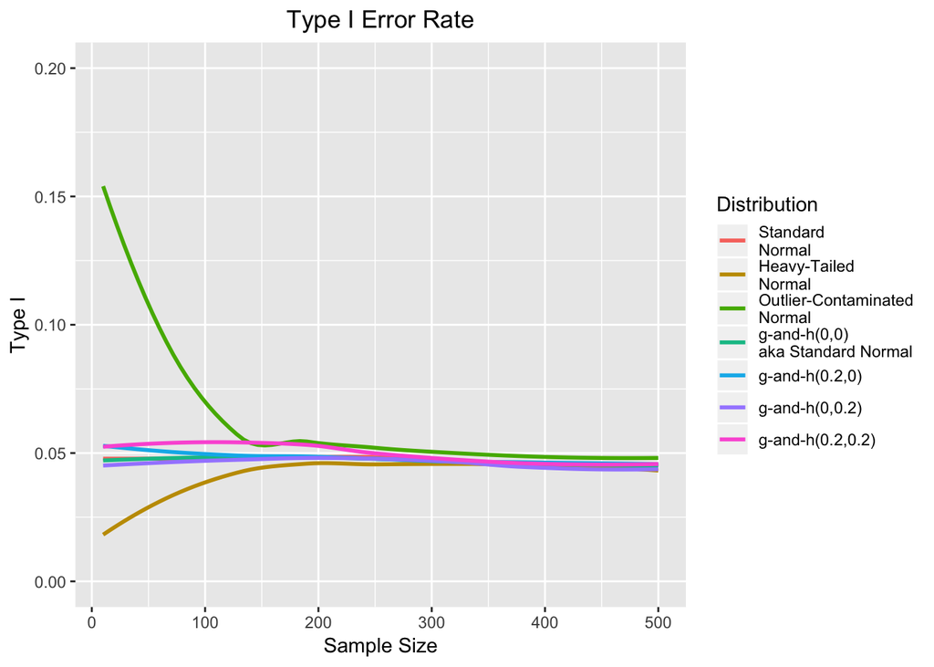

The actual power, on the other hand, is the proportion of the calculated t-statistics that reject the null hypothesis. Suppose the test statistic’s actual probability coverage is close to the nominal. In that case, the corresponding lines in the nominal and actual power plots should roughly match, while disparate line trends reflect a discrepancy between the nominal and actual power. As seen in the plots below, at the smallest of sample sizes, nominal power overestimates the actual power at least moderately for all methods except the two standard normal distributions as well as the g-and-h distribution with $g = 0.2$ and $h = 0$ (aka the skewed, normal-tailed distribution). **g-and-h(0,0.2)** (symmetric, heavy-tailed distribution) and **g-and-h(0.2,0.2)** (skewed and heavy-tailed distribution) do not stabilize around their nominal levels until sample sizes of $n > 100$, the outlier-contaminated distribution until approximately $n = 200$, and the heavy-tailed distribution until $n > 400$.

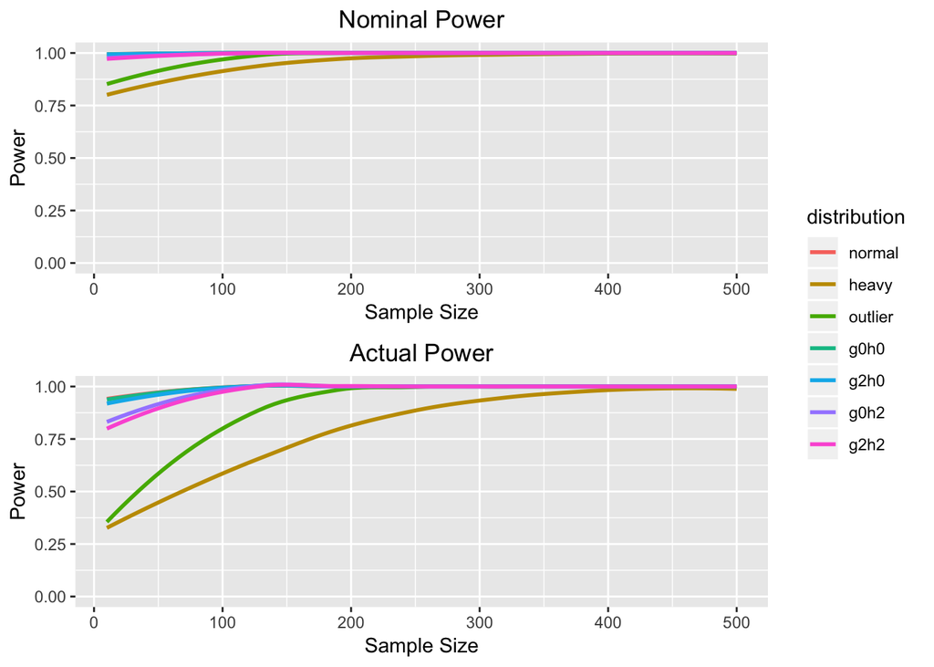

## References

Auguie, Baptiste. 2017. *GridExtra: Miscellaneous Functions for "Grid" Graphics*. https://CRAN.R-project.org/package=gridExtra.

Bache, S.M., and H. Wickham. 2016. *Magrittr: A Forward-Pipe Operator for R*. https://CRAN.R-project.org/package=magrittr.

Basu, S., and A. DasGupta. 1995. “Robustness of Standard Confidence Intervals for Location Parameters Under Departures from Normality.” *Annals of Statistics* 23: 1433–42.

Benjamini, Y. 1983. “Is the T Test Really Conservative When the Parent Distribution Is Long-Tailed?” *Journal of the American Statistical Association* 78: 645–54.

Bessel, F.W. 1818. *Fundamenta Astronomiae Pro Anno Mdcclv Deducta Ex Observationibus Viri Incomparabilis James Bradley in Specula Astronomica Grenovicensi Per Annos 1750-1762 Institutis*. Königsburg: Friedrich Nicolovius.

Dowle, Matt, and Arun Srinivasan. 2019. *Data.table: Extension of ‘Data.frame‘*. https://CRAN.R-project.org/package=data.table.

Henry, Lionel, and Hadley Wickham. 2021. *Rlang: Functions for Base Types and Core R and ’Tidyverse’ Features*. https://CRAN.R-project.org/package=rlang.

Henry, L., H. Wickham, and RStudio. 2020. *Purrr: Functional Programming Tools*. https://CRAN.R-project.org/package=purrr.

Hill, R.W., and W.J. Dixon. 1982. “Robustness in Real Life: A Study of Clinical Laboratory Data.” *Biometrics* 72: 377–96.

Micceri, T. 1989. “The Unicorn, the Normal Curve, and Other Improbable Creatures.” *Psychological Bulletin* 105: 156–66.

Multach, Matthew D. 2021. “The Robustification of the Lasso and the Elastic Net: Utility in Practical Research Settings.” 2021. https://digitallibrary.usc.edu/Share/ejfa2qke4l58668s5rs615s347t6p62g.

Newcomb, S. 1886. “A Generalized Theory of the Combination of Observations so as to Obtain the Best Result.” *American Journal of Mathematics* 8: 343–66.

Pedersen, W.C., L.C. Miller, A.D. Putcha-Bhagavatula, and Y. Yang. 2002. “Evolved Sex Differences in Sexual Strategies: The Long and Short of It.” *Psychological Science* 13: 157–61.

R Core Team. 2019a. *R: A Language and Environment for Statistical Computing*. Vienna, Austria: R Foundation for Statistical Computing. https://www.R-project.org/.

———. 2019b. *R: A Language and Environment for Statistical Computing*. Vienna, Austria: R Foundation for Statistical Computing. https://www.R-project.org/.

Revelle, William. 2019. *Psych: Procedures for Psychological, Psychometric, and Personality Research*. Evanston, Illinois: Northwestern University. https://CRAN.R-project.org/package=psych.

Rousseeuw, P.J., and A.M. Leroy. 1987. *Robust Regression & Outlier Detection*. New York, New York: Wiley.

Westfall, P.H., and S.S. Young. 1993. *Resampling Based Multiple Testing*. New York: Wiley.

Wickham, Hadley. 2016. *Ggplot2: Elegant Graphics for Data Analysis*. Springer-Verlag New York. https://ggplot2.tidyverse.org.

Wilcox, R.R. 1990. “Comparing the Means of Two Independent Groups.” *Biometrical Journal* 32: 771–80.

———. 2016. *Introduction to Robust Estimation and Hypothesis Testing*. 4th ed. Academic Press.

Wilcox, R.R., D.M. Erceg-Hurn, F. Clark, and M. Carlson. 2013. “Comparing Two Independent Groups via the Lower and Upper Quantiles.” *Journal of Statistical Computation and Simulation* 84 (7): 1543–51.

Xie, Yihui. 2021. *Xaringan: Presentation Ninja*. https://CRAN.R-project.org/package=xaringan.